# 11.1.3. Aggregated binomial: Chimpanzees again, condensed

```r
library(rethinking)
```

En el contexto de datos de chimpancés, todos los modelos calcularon la probabilidad de observar cero o uno tirando de la palanca izquierda. Los modelos lo hicieron porque los datos se organizaron de tal manera que cada fila describe el resultado de un solo tirón. Pero en principio se podrían organizar los mismos datos de diferente manera. Mientras no nos importe el orden de los tirones individuales, la misma información está contenida en un recuento de cuántas veces cada individuo tiró de la palanca de la izquierda, para cada combinación de variables predictoras. Este código se meustra a continuación.

```r
data(chimpanzees)
d <- chimpanzees
d$treatment <- 1 + d$prosoc_left + 2*d$condition
d$side <- d$prosoc_left + 1 # right 1, left 2
d$cond <- d$condition + 1 # no partner 1, partner 2
d_aggregated <- aggregate(
d$pulled_left ,
list( treatment=d$treatment , actor=d$actor ,
side=d$side , cond=d$cond ) ,
sum )
colnames(d_aggregated)[5] <- "left_pulls"
```

```r
head(d_aggregated,8)
```

|  | treatment | actor | side | cond | left_pulls |
| --- | --- | --- | --- | --- | --- |
| 1 | 1 | 1 | 1 | 1 | 6 |
| 2 | 1 | 2 | 1 | 1 | 18 |
| 3 | 1 | 3 | 1 | 1 | 5 |
| 4 | 1 | 4 | 1 | 1 | 6 |
| 5 | 1 | 5 | 1 | 1 | 6 |
| 6 | 1 | 6 | 1 | 1 | 14 |
| 7 | 1 | 7 | 1 | 1 | 14 |
| 8 | 2 | 1 | 2 | 1 | 9 |

Obsrvamos que el actor numero 2 de los 18 intentos siempre eligió la palanca izquierda. Tomando esto en cuenta definimos el modelo:

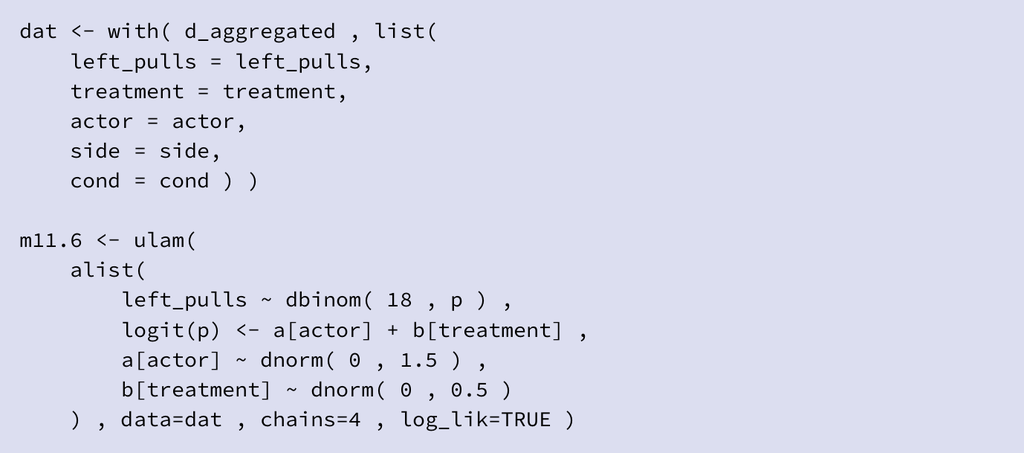

Ahora comparamos los modelos

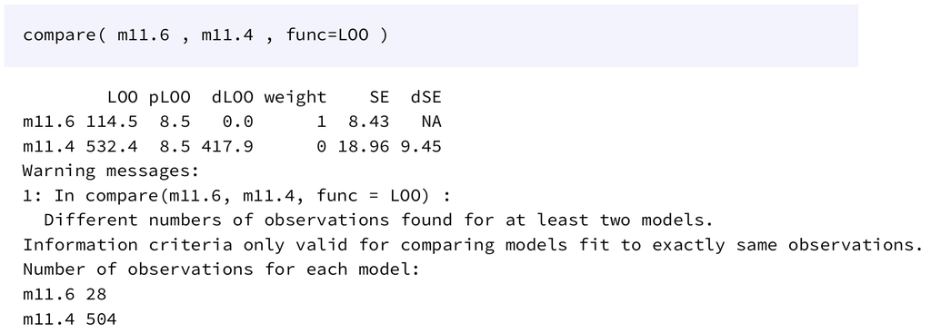

Aunque ambos modelos tienen la misma posterior, el resumen LOOIS para ambos modelo muestran muy diferentes resultados. La principal razón ed que el modelo m11.6 contienen un factor extra en su log-probabilities dado la forma en que está organizado el texto.